# Team.Rmd

Zack Larson, Julia Lundstrum, and Nikole Slinger

## Reading the Data

```r
choco <- read.csv("https://raw.githubusercontent.com/xdaiISU/ds202materials/master/hwlabs/data/choco.csv")
str(choco)
```

```
## 'data.frame':    2312 obs. of  13 variables:
##  $ REF                 : int  2454 2458 2454 797 797 1015 1019 1011 1019 1011 ...
##  $ Company             : chr  "5150" "5150" "5150" "A. Morin" ...
##  $ Location            : chr  "U.S.A." "U.S.A." "U.S.A." "France" ...
##  $ Date                : int  2019 2019 2019 2012 2012 2013 2013 2013 2013 2013 ...
##  $ Bean_Origin         : chr  "Madagascar" "Dominican Republic" "Tanzania" "Peru" ...
##  $ Specific_Bean_Origin: chr  "Bejofo Estate, batch 1" "Zorzal, batch 1" "Kokoa Kamili, batch 1" "Peru" ...
##  $ Cocoa_Percent       : num  76 76 76 63 70 70 63 70 70 70 ...
##  $ Ingredients         : chr  "3- B,S,C" "3- B,S,C" "3- B,S,C" "4- B,S,C,L" ...
##  $ Characteristics1    : chr  "cocoa" "cocoa" "rich cocoa" "fruity" ...
##  $ Characteristics2    : chr  "blackberry" "vegetal" "fatty" "melon" ...
##  $ Characteristics3    : chr  "full body" "savory" "bready" "roasty" ...
##  $ Characteristics4    : chr  NA NA NA NA ...
##  $ Rating              : num  3.75 3.5 3.25 3.75 3.5 4 4 3.75 3.5 3.25 ...
```

## Searching for the Best Chocolates

#### 1.

The ratings are distributed unevenly. As you can see in the histogram, there are a lot more ratings greater than 2.5 than lower than 2.5, making it unsymmetrical and left skewed. An interesting feature is the fact that there appears to be no chocolate with a rating between 3.0 and 3.25 when we would expect there to be many. There are also a few outliers visible below 2.0.

In the box plot, you can also see that the data is more relevant in the upper ratings like 3 and 3.5 than down below in the 2.5 and 2 ratings, Since the ratings vary from 1.0 to 4.0, the average for the data should be around 2.5 but is in fact 3.184 showing that it’s skewed more to the higher ratings. There are not many outliers, there are a few 1.0 ratings, but overall that is expected with such a large collection of data.

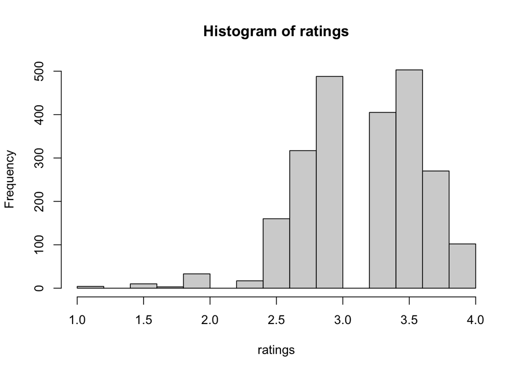

```r
ratings <- choco$Rating
hist(ratings)
```

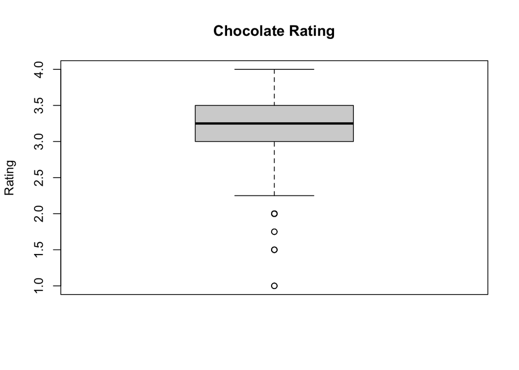

```r
boxplot(ratings, main = 'Chocolate Rating', ylab = 'Rating')
```

```r
averageRating <- mean(ratings)
averageRating
```

```
## [1] 3.184083
```

#### 2.

The location of the company appears to have little effect on the rating of the chocolate because there are multiple companies with the same location but with different chocolate ratings. For example, companies that are located in U.S.A. seem to have ratings that range between about 2.0 and 4.0. However, one way that location may have a small effect on chocolate rating is that there may be more reviewers in one country than in another. For example, there are a lot more ratings of Australian companies than Czech Republic companies because the population of Australia is that much bigger.

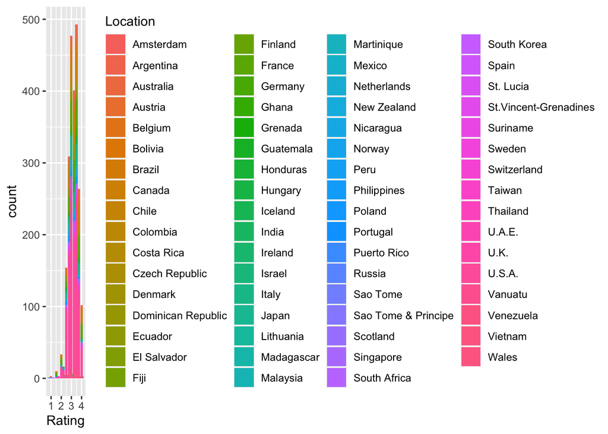

```r
library(ggplot2)
ggplot(aes(x = Rating,fill=Location),data=choco) + geom_bar()
```

#### 3.

As shown in the scatter plot, the columns showing the cocoa percentage and the rating of the chocolate bar seem to have no linear relationship at all. Also as shown in the cor() function, the correlation coefficient is r = -0.151, meaning that the 2 variables show extremely little strength of correlation (if anything, there is a very small negative correlation). One note to make is that a scatter plot is not the best choice of graph here because there are so many ratings and cocoa percentages that are similar or equal in value so overlapping in values shown in the scatter plot can be overlooked.

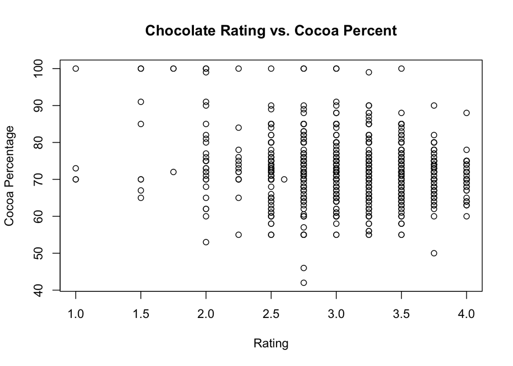

```r
plot(choco$Rating,choco$Cocoa_Percent, main = 'Chocolate Rating vs. Cocoa Percent', xlab = 'Rating', ylab = 'Cocoa Percentage')
```

```r
cor(choco$Rating,choco$Cocoa_Percent)
```

```
## [1] -0.1510178
```

## Collaboration Workflow - Zack Larson

#### 4.

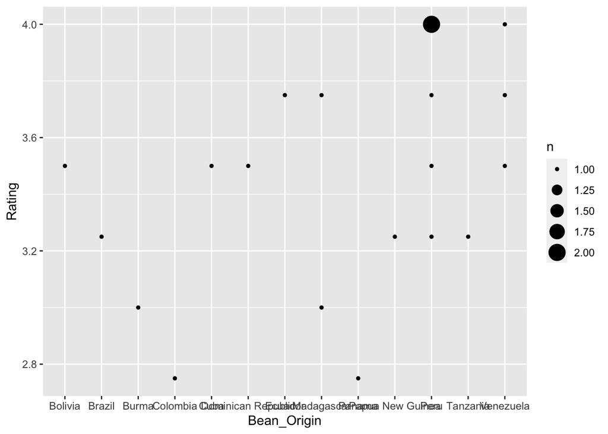

```r
 best20 = choco[order(ave(choco$Rating), decreasing= TRUE),]
best20 = best20[1:20,]
ggplot(best20, aes(x=Bean_Origin, y=Rating)) + geom_count()
```

```r
best20
```

```
##     REF  Company Location Date        Bean_Origin    Specific_Bean_Origin
## 1  2454     5150   U.S.A. 2019         Madagascar  Bejofo Estate, batch 1
## 2  2458     5150   U.S.A. 2019 Dominican Republic         Zorzal, batch 1
## 3  2454     5150   U.S.A. 2019           Tanzania   Kokoa Kamili, batch 1
## 4   797 A. Morin   France 2012               Peru                    Peru
## 5   797 A. Morin   France 2012            Bolivia                 Bolivia
## 6  1015 A. Morin   France 2013          Venezuela                   Chuao
## 7  1019 A. Morin   France 2013               Peru    Chanchamayo Province
## 8  1011 A. Morin   France 2013            Ecuador                Equateur
## 9  1019 A. Morin   France 2013               Peru    Chanchamayo Province
## 10 1011 A. Morin   France 2013             Brazil                  Brazil
## 11 1015 A. Morin   France 2013   Papua New Guinea        Papua New Guinea
## 12 1019 A. Morin   France 2013               Peru                   Piura
## 13 1011 A. Morin   France 2013         Madagascar     Madagascar, Criollo
## 14 1015 A. Morin   France 2013              Burma                Birmanie
```

[output cut: 48 more lines]

#### 5.

```r
library(tidyverse)
characteristicsRatings = choco[,c(9,10,11,12,13)]
df2 <- data.frame(Characteristics1 = c(characteristicsRatings[,"Characteristics2"], characteristicsRatings[,"Characteristics3"],characteristicsRatings[,"Characteristics4"]),characteristicsRatings[,"Rating"])##Get all characteristics into one column
groupBest <- aggregate(characteristicsRatings....Rating..~Characteristics1, df2, FUN=mean)##Get average rating of each characteristic
groupBest <- groupBest %>% slice_max(characteristicsRatings....Rating..)##Show ones with highest average rating
groupBest##Shows list of all characteristics with an average rating of 4(max)
```

```
##    Characteristics1 characteristicsRatings....Rating..
## 1     burnt brownie                                  4
## 2          cinnamon                                  4
## 3             clove                                  4
## 4    delicate cocoa                                  4
## 5    delicate fruit                                  4
## 6             dense                                  4
## 7     distinquished                                  4
## 8      gentle roast                                  4
## 9             homey                                  4
## 10   intense pepper                                  4
## 11      raspberries                                  4
## 12    roasted cocoa                                  4
## 13          rounded                                  4
## 14        tangerine                                  4
## 15      tart citrus                                  4
## 16  unripened fruit                                  4
## 17     wild berries                                  4
```

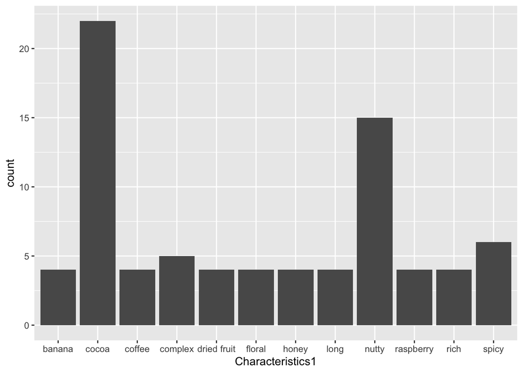

```r
df2 <- df2 %>% filter(characteristicsRatings....Rating.. == 4,Characteristics1!="<NA>")##Get rid of N/A data and filter for top ratings
df2 <- df2 %>% group_by(Characteristics1) %>% filter(n() > 3)##Filter for most used characteristics in the high ratings
ggplot(df2, aes(x=Characteristics1)) + geom_bar()##graph
```

## Collaboration Workflow - Nikole Slinger

#### 4.

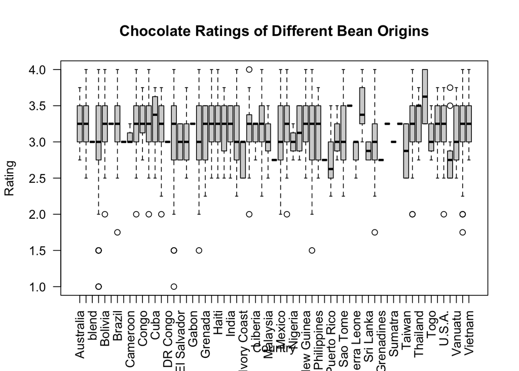

```r
# creating boxplots of bean origins and their ratings
boxplot(choco$Rating ~ choco$Bean_Origin, main = "Chocolate Ratings of Different Bean Origins",
        xlab = "Country", ylab = "Rating", las = 2)
```

From looking at the multiple boxplots, we can see that the most common median value is between 3.0 and 3.25. The country of Tobago appears to have the highest chocolate rating interquartile range, while Uganda seems to have the lowest chocolate rating interquartile range.

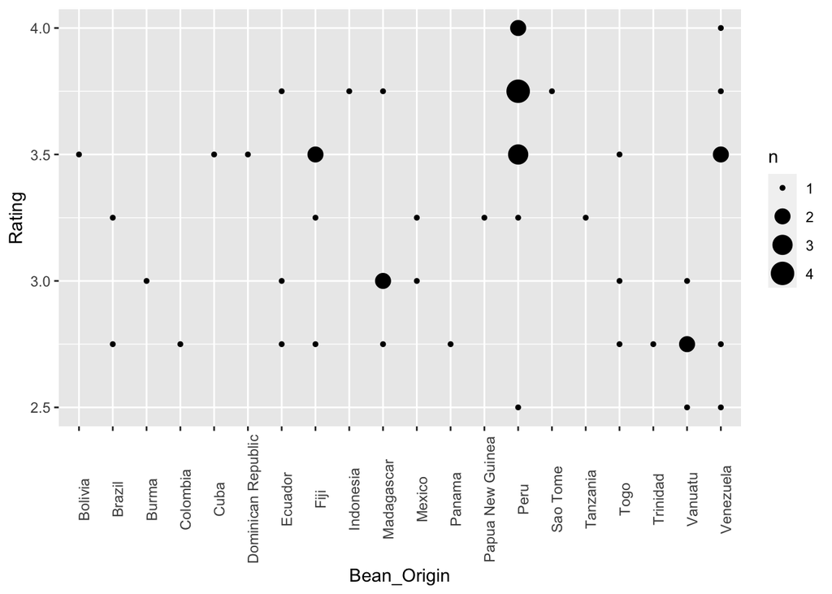

```r
# only using top 50
ratings = choco[order(ave(choco$Rating), decreasing= TRUE), ]
ratings = ratings[1:50, ]
ggplot(ratings, aes(x = Bean_Origin, y = Rating)) + geom_count() +
  theme(axis.text.x = element_text(angle = 90))
```

#### 5.

```r
library(tidyverse)

# looking at companies with highest chocolate ratings
companydata <- choco[,c(2, 13)]
codata <- data.frame(company = c(companydata[,"Company"]), companydata[,"Rating"])
topcompanies <- aggregate(companydata....Rating..~company, codata, FUN=mean)
# finding companies with chocolate ratings above 3.75
topcompanies <- topcompanies %>% slice_max(companydata....Rating.. > 3.75)
topcompanies
```

```
##                                company companydata....Rating..
## 1 Heirloom Cacao Preservation (Zokoko)                3.875000
## 2                    Idilio (Felchlin)                3.775000
## 3                               Matale                3.812500
## 4                               Ocelot                3.875000
## 5                               Patric                3.791667
## 6               Tobago Estate (Pralus)                4.000000
```

For my analysis I looked for the companies with the top average chocolate rating. I found that the companies returned above had the highest chocolate ratings (those above 3.75). The location of these companies include U.S.A, Switzerland, Australia, Scotland, and France while the bean origins include Bolivia, Venezuela, Madagascar, and Tobago (among others). Even though the company locations are not located where the beans come from, we know from previous anaylses that bean origin is what has a larger effect on chocolate rating.